# Line graphs

# 7 Combining compatible geoms

It is hard to read individual values in the line graphs above. In the next plot, we’ll add points to make this clearer.

As long as the geoms are compatible, we can layer them on top of one another to further customize a graph.

For example, we can add points to our line graph using the `+` sign to add a second `geom` layer with `geom_point()`:

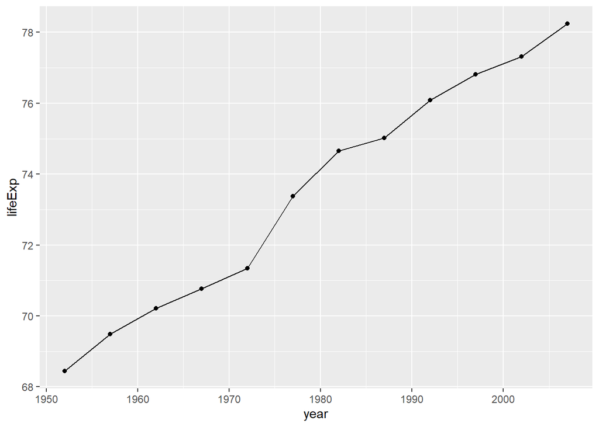

```r
# Simple line graph with points
ggplot(data = gap_US,
       mapping = aes(x = year,
                     y = lifeExp)) +
  geom_line() +
  geom_point()
```

We can create a more attractive plot by customizing the size and color of our geoms.

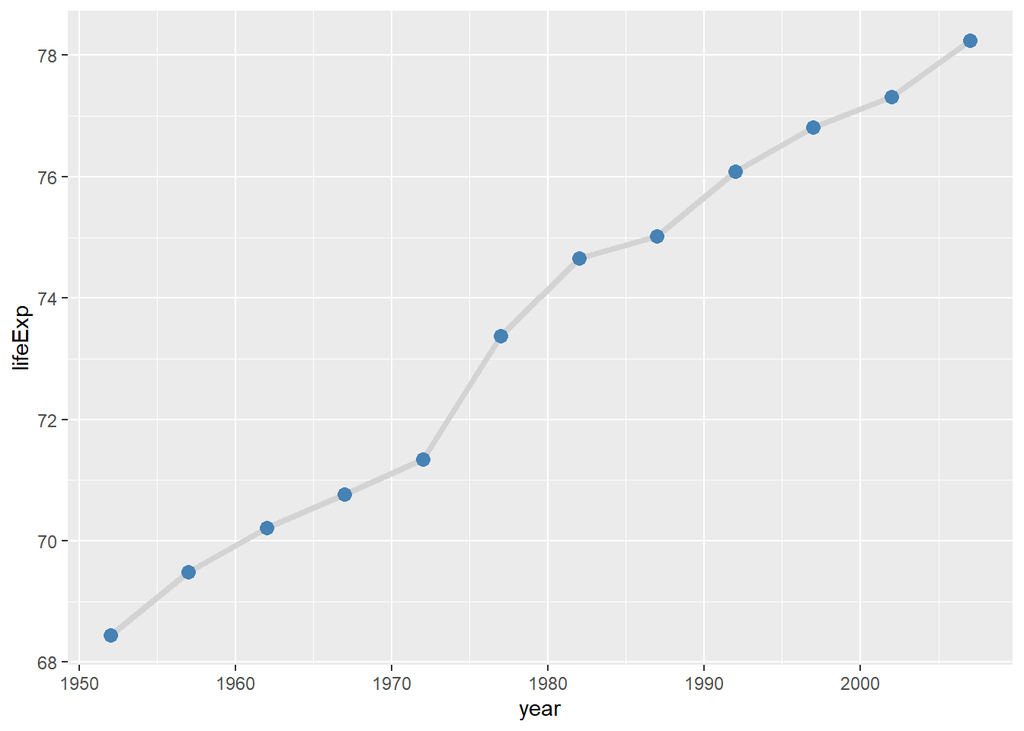

```r
# line graph with points and improved aesthetics
ggplot(data = gap_US,
       mapping = aes(x = year,
                     y = lifeExp)) +
  geom_line(size = 1.5,
            color = "lightgrey") +
  geom_point(size = 3,
             color = "steelblue")
```

**Practice Question**

Building on the code above, visualize the relationship between time the GPD per capita `gap_US` data frame with both points and lines.

Change the line type of the line and the color of the points to any valid values that you like.